# Covid Cases

11 October 2020

#### Outcomes

- Download and load public data sets
- Read and interpret metadata
- Evaluate general claims using data, in the presence of missing data
- Create and interpret interaction plots

#### Instructions

- Answer the following questions, and show all your R code.
- Upload your submission to Canvas in nicely formatted HTML generated from Rstudio.

Download the [COVID-19 Case Surveillance Public Use Data](https://data.cdc.gov/Case-Surveillance/COVID-19-Case-Surveillance-Public-Use-Data/vbim-akqf) from the US Center for Disease Control (CDC). Click on the “Export” button in the top right corner next to download the actual data set.

*Hint: It might be useful to create a new numeric column for severity based on the values of the `hosp, icu, death` columns. If you do this, make sure you explain the meaning and rationale behind your choices.*

# Questions

## 1 - Reading the Documentation

*a) Describe this data set at a high level. What does each row represent?*

Each row represents a deidentified patient.

- cdc_report_dt represents initial case report date to CDC and is a Date & Time type.
- pos_spec_dt represents date of first positive specimen collection and is a Date & Time type.
- onset_dt represents symptom onset date, if symptomatic and is a Date & Time type.
- current_status is the case status: labrotory-confirmed case; probable case and is plain text
- sex the is sex of the patient… This could be male, female, unknown, other and this is plain text.
- age_goup is the age category of the patient. This could be several different categories: 0-9 Years; 10-19 Years; 20-29 Years; 30-39 Years; 40-49 Years; 50-59 Years; 60-69 Years; 70-79 Years and 80+ years
- race and ethnicity (combined) represents the patients race and ethnicity. The categories are: Race and ethnicity (combined): Hispanic/Latino; American Indian / Alaska Native, Non-Hispanic; Asian, Non-Hispanic; Black, Non-Hispanic; Native Hawaiian / Other Pacific Islander, Non-Hispanic; White, Non-Hispanic; Multiple/Other, Non-Hispanic. This is plain text.
- hosp_yn is the patients hospitilization status. The columns ending with “yn” usually have “Yes” or “No” for their values. This is plain text.
- icu_yn is the patients ICU admission status. This is plain text.
- death_yn represents weather or not the patient has died. This is stored in plain text values as “Yes” or “No”.
- medcond_yn represents weather or not the patient has presence of underlying comordibidity or disease. This is stored in plain text.

_b) How many rows and columns do you expect to see based on the website?

- I expect this data to have 11 columns and 4,481,062 rows because that is what the documentation claims.

Load the data into R.

Is this reflected in the data?

```r
covid_data = read.csv("COVID-19_Case_Surveillance_Public_Use_Data.csv")
dim(covid_data)
```

```
## [1] 4481062      11
```

```r
row_count = dim(covid_data)[1]
```

## 2 - Missing Data

*There are few `NA` values in this data, but much of the data is missing, unknown, or blank. Which columns have the highest proportion of missing data? Why might these be missing?*

```r
# sex missing values
count_missing = function(data) {
  row_count = dim(data)[1]
  for (column in colnames(data)) {
    # "Missing"
    missing = sum(data[,column] == "Missing", na.rm = TRUE)
    # unknown
    unknown = sum(data[,column] == "Unknown", na.rm = TRUE)
    # "N/A"
    na = sum(is.na(data[,column]))
    # blank or ""
    blank = sum(data[,column] == "", na.rm = TRUE)
    total = sum(missing,unknown,na,blank)
    percent_missing = total / row_count
    result = c(column, total, total/row_count)
    print(result)
    # print(column)
    # print(total)
    # print(total/row_count)
  }

}

count_missing(covid_data)
```

```
## [1] "cdc_report_dt" "0"             "0"
## [1] "pos_spec_dt"       "2957494"           "0.659998455723219"
## [1] "onset_dt"          "2113224"           "0.471589993622048"
## [1] "current_status" "0"              "0"
## [1] "sex"                "54045"              "0.0120607570259014"
## [1] "age_group"           "5281"                "0.00117851527160303"
## [1] "Race.and.ethnicity..combined." "1895805"
## [3] "0.423070468563033"
## [1] "hosp_yn"           "2138483"           "0.477226827033413"
## [1] "icu_yn"            "3932347"           "0.877548000898001"
## [1] "death_yn"          "2269410"           "0.506444677623296"
## [1] "medcond_yn"        "3536092"           "0.789119186478562"
```

```r
# should have used lapply
```

- icu_yn has the most values “Missing”, “Unknown” blank or NA. medcond_yn has the second most missing values. pos_spec_dt is the third. These might be missing because they are unknown or the data was unavailable. There is also probably a lot of missing data because the situation is hectic. Doctors may not have time to record this data. If a patient is feeling well they may leave unexpectedly.

## 3 - Age Risk

*The [CDC states](https://www.cdc.gov/coronavirus/2019-ncov/need-extra-precautions/older-adults.html) “Among adults, the risk for severe illness from COVID-19 increases with age, with older adults at highest risk.” Does the data support this claim?*

*Hint 1: It might be useful to think about these COVID illness rates by age after adjusting for the relative sizes of each age group in the country. You’ll need to bring in another data source to do this.*

```r
# from the notes
covid = read.csv("COVID-19_Case_Surveillance_Public_Use_Data.csv")

severity = rep(0, times = nrow(covid))
severity[covid$hosp_yn == "Yes"] = 1
severity[covid$icu_yn == "Yes"] = 2
severity[covid$death_yn == "Yes"] = 3

covid$severity = severity


# young
young_adults = covid[(covid$age_group == "20 - 29 Years" | covid$age_group == "30 - 39 Years"),]

# dim(young_adults)
print("Young adults:")
```

```
## [1] "Young adults:"
```

```r
dim(young_adults[young_adults$severity == 0,])[1] / dim(young_adults)[1]
```

```
## [1] 0.9695071
```

```r
dim(young_adults[young_adults$severity == 1,])[1] / dim(young_adults)[1]
```

```
## [1] 0.02653641
```

```r
dim(young_adults[young_adults$severity == 2,])[1] / dim(young_adults)[1]
```

```
## [1] 0.002583278
```

```r
dim(young_adults[young_adults$severity == 3,])[1] / dim(young_adults)[1]
```

```
## [1] 0.001545762
```

```r
# middle aged adults
middle_adults = covid[(covid$age_group == "40 - 49 Years" | covid$age_group == "50 - 59 Years"),]
# dim(middle_adults)
print("middle adults")
```

```
## [1] "middle adults"
```

```r
dim(middle_adults[middle_adults$severity == 0,])[1] / dim(middle_adults)[1]
```

```
## [1] 0.9190233
```

```r
dim(middle_adults[middle_adults$severity == 1,])[1] / dim(middle_adults)[1]
```

```
## [1] 0.06180274
```

```r
dim(middle_adults[middle_adults$severity == 2,])[1] / dim(middle_adults)[1]
```

```
## [1] 0.008141432
```

```r
dim(middle_adults[middle_adults$severity == 3,])[1] / dim(middle_adults)[1]
```

```
## [1] 0.01123673
```

```r
# elderly
elder_adults = covid[(covid_data$age_group == "60 - 69 Years" | covid_data$age_group == "70 - 79 Years" | covid_data$age_group == "80+ Years"),]
dim(elder_adults)
```

```
## [1] 965353     12
```

```r
print("elder adults")
```

```
## [1] "elder adults"
```

```r
dim(elder_adults[elder_adults$severity == 0,])[1] / dim(elder_adults)[1]
```

```
## [1] 0.7310766
```

```r
dim(elder_adults[elder_adults$severity == 1,])[1] / dim(elder_adults)[1]
```

```
## [1] 0.1320626
```

```r
dim(elder_adults[elder_adults$severity == 2,])[1] / dim(elder_adults)[1]
```

```
## [1] 0.01420724
```

```r
dim(elder_adults[elder_adults$severity == 3,])[1] / dim(elder_adults)[1]
```

```
## [1] 0.1229426
```

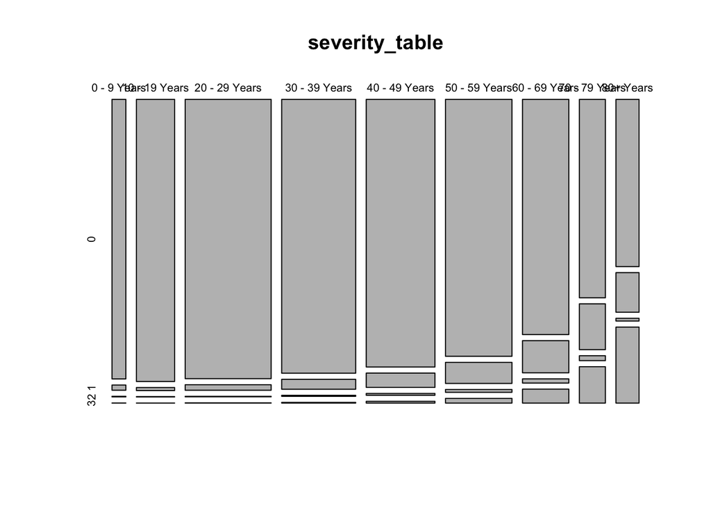

```r
covid = covid[covid$age_group != "Unknown",]
severity_table = table(covid$age_group, covid$severity)
plot(severity_table)
```

This table shows that as age increases the proportion of people in the 1 and 3 categories increases and people in the 0 category decreases. We see that people who are not in the hospital are young. More people who are hospitalized or die are older. People in category 2 are uniformly small accross the board.

```r
# TODO
# unique(covid_data$age_group)




young_boolean_mask = covid_data$age_group == "0 - 9 Years" | covid_data$age_group ==  "10 - 19 Years"
young = covid_data[young_boolean_mask,]
young_dead = young[young$death_yn == "Yes",]
dim(young_dead)[1] / dim(young)[1]
```

```
## [1] 0.0004270382
```

```r
mid_boolean_mask = covid_data$age_group == "20 - 29 Years" | covid_data$age_group == "30 - 39 Years" | covid_data$age_group == "30 - 39 Years" | covid_data$age_group == "40 - 49 Years"
mid = covid_data[mid_boolean_mask,]
mid_dead = mid[mid$death_yn == "Yes",]
dim(mid_dead)[1] / dim(mid)[1]
```

```
## [1] 0.002925179
```

```r
old_boolean_mask = covid_data$age_group == "50 - 59 Years" | covid_data$age_group == "60 - 69 Years" | covid_data$age_group == "70 - 79 Years" | covid_data$age_group == "80+ Years"
old = covid_data[old_boolean_mask,]


old_dead = old[old$death_yn == "Yes",]

dim(old_dead)[1] / dim(old)[1]
```

```
## [1] 0.0792112
```

## 4 - Medical Condition Risk

*The [CDC states](https://www.cdc.gov/coronavirus/2019-ncov/need-extra-precautions/people-with-medical-conditions.html) “People of any age with certain underlying medical conditions are at increased risk for severe illness from COVID-19” Does the data support this claim?*

```r
# TODO
# unique(covid_data$medcond_yn)
boolean_mask_medcond_death = (covid_data$medcond_yn == "Yes" | covid_data$medcond_yn == "No") & (covid_data$death_yn == "Yes" | covid_data$death_yn == "No")
medcond_alive_or_dead = covid_data[boolean_mask_medcond_death,]

dim(medcond_alive_or_dead)
```

```
## [1] 677680     11
```

```r
# has medical condition and is alive
has_cond_and_alive = medcond_alive_or_dead[(medcond_alive_or_dead$medcond_yn == "Yes" & medcond_alive_or_dead$death_yn == "No"),]
print("percent of people with medical condition who survived")
```

```
## [1] "percent of people with medical condition who survived"
```

```r
dim(has_cond_and_alive)[1] / dim(medcond_alive_or_dead)[1]
```

```
## [1] 0.4690783
```

```r
# has medical condition and is dead
has_cond_and_dead = medcond_alive_or_dead[(medcond_alive_or_dead$medcond_yn == "Yes" & medcond_alive_or_dead$death_yn == "Yes"),]
print("percent of people with medical condition who died")
```

```
## [1] "percent of people with medical condition who died"
```

```r
dim(has_cond_and_dead)[1] / dim(medcond_alive_or_dead)[1]
```

```
## [1] 0.09532228
```

```r
# does not have medical condition and is alive
no_cond_and_alive = medcond_alive_or_dead[(medcond_alive_or_dead$medcond_yn == "No" & medcond_alive_or_dead$death_yn == "No"),]
print("percent of people with NO medical condition who survived")
```

```
## [1] "percent of people with NO medical condition who survived"
```

```r
dim(no_cond_and_alive)[1] / dim(medcond_alive_or_dead)[1]
```

```
## [1] 0.4322689
```

```r
# does not have medical condition and died
no_cond_and_dead = medcond_alive_or_dead[(medcond_alive_or_dead$medcond_yn == "No" & medcond_alive_or_dead$death_yn == "Yes"),]
print("percent of people with NO medical condition who died")
```

```
## [1] "percent of people with NO medical condition who died"
```

```r
dim(no_cond_and_dead)[1] / dim(medcond_alive_or_dead)[1]
```

```
## [1] 0.00333048
```

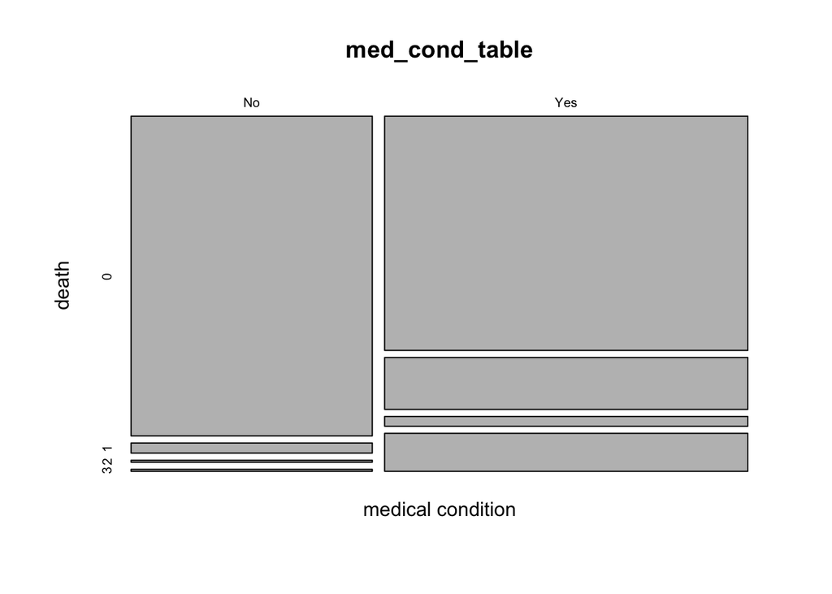

```r
# med_cond_table = table(medcond_alive_or_dead$medcond_yn,medcond_alive_or_dead$death_yn)
covid4 = covid[(covid$medcond_yn == "Yes" | covid$medcond_yn == "No"),]
med_cond_table = table(covid4$medcond_yn,covid4$severity)

plot(med_cond_table, xlab = "medical condition", ylab = "death")
```

I subsetted the data so that I only have entries that contain data on medical condition and weather or not they died. We can see that more people who have a medical condition die. Because the numbers in this data seem a little of I created a table and plotted it just to be sure. From the plot of the table I can see that the people with medical conditions much more often fall into categories 1,2 and 3 than people without a medical condition. This supports the claim people with medical conditions are at higher risk. It is worthwhile to mention that this may be biased. People with medical conditions are more likely to check themselves into the hospital.

## 5 - Interaction Effects

*In statistics, an **interaction effect** is when two or more variables have a non additive effect in the value of some response. In the questions above, we explored the severity of COVID-19 (response) given variables age and medical condition. Do age and medical condition have an interaction effect in the severity of COVID-19?*

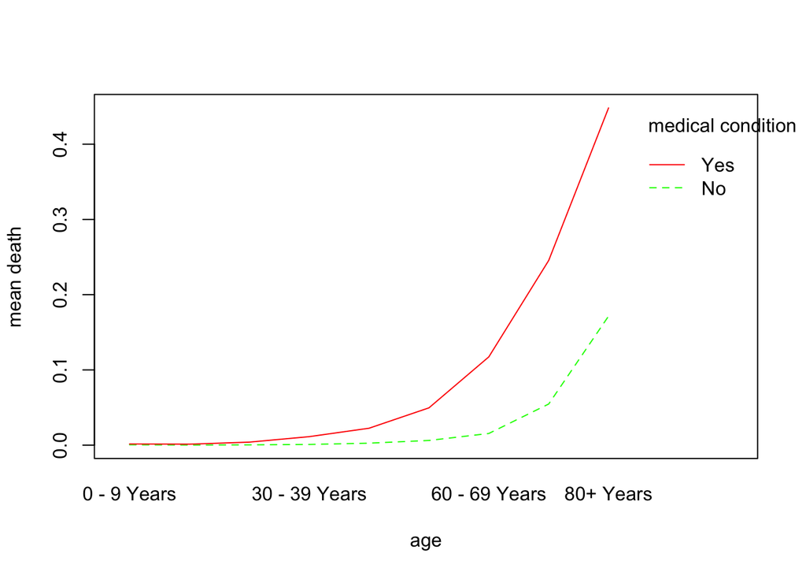

```r
covid5 = covid[(covid$medcond_yn == "Yes" | covid$medcond_yn == "No"),]
interaction.plot(covid5$age_group, covid5$medcond_yn,covid5$death_yn == "Yes", xlab = "age", ylab = "mean death", trace.label = "medical condition", col =  c("green", "red"))
```

Yes age and medical condition have an effect on severity of covid-19. We can see that as age increases deaths increase. We can also see that in every age category someone with with a medical condition is more likely to die.

## 6 - Your Question

_Come up with your own question about COVID-19, and answer it using this data set. Does sex or race (white/non-white for simplicity) have any effect on the death of people.

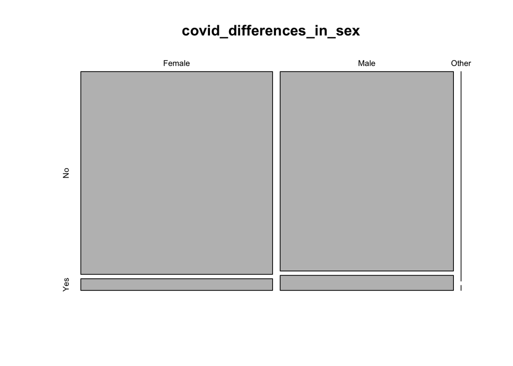

```r
mask6 = (covid_data$sex == "Male" | covid_data$sex == "Female" | covid_data$sex == "Other") & (covid_data$death_yn == "Yes" | covid_data$death_yn == "No")
covid6 = covid_data[mask6,]
covid_differences_in_sex = table(covid6$sex, covid6$death_yn)
plot(covid_differences_in_sex)
```

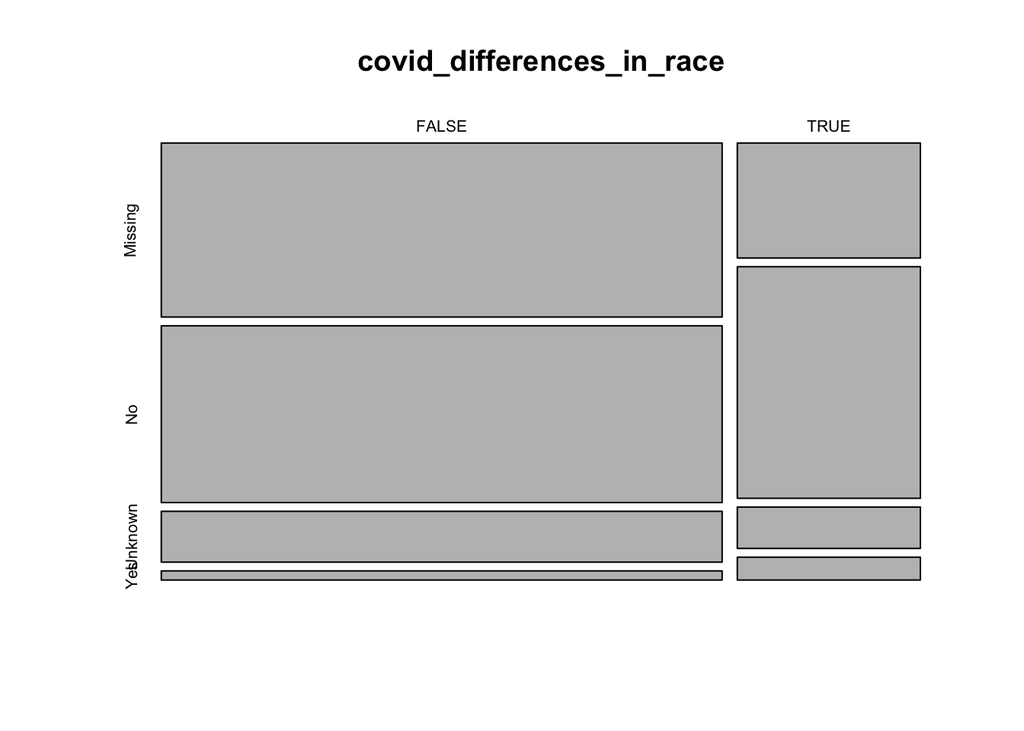

```r
# race
covid_data$white = covid_data$Race.and.ethnicity..combined. == "White, Non-Hispanic"
covid_differences_in_race = table(covid_data$white, covid_data$death_yn)
plot(covid_differences_in_race)
```

```r
unique(covid_data$Race.and.ethnicity..combined.)
```

```
## [1] "Multiple/Other, Non-Hispanic"
## [2] "Unknown"
## [3] "Hispanic/Latino"
## [4] "Black, Non-Hispanic"
## [5] "White, Non-Hispanic"
## [6] "Asian, Non-Hispanic"
## [7] "American Indian/Alaska Native, Non-Hispanic"
## [8] "Native Hawaiian/Other Pacific Islander, Non-Hispanic"
## [9] NA
```